# Revisión del paper: Convex Optimization for Big Data

Eduardo Hidalgo

May 30, 2018

# Optimización sobre conjuntos convexos para análisis de grandes cantidades de información

## Temas del Paper

- Resúmen e importancia del tema
- Métodos de Primer Órden
  - Funciones convexas *suaves*
  - Funciones compuestas (una *suave* y otra *no suave*)
  - Funciones convexas *no suaves*
- Escalabilidad para conjuntos de grandes datos mediante *aleatoriazación*
  - Métodos de Descenso Coordinado
  - Métodos de Descenso *Probabilístico*
  - Álgebra Lineal *Aleatorizada*
- Procesamiento en Paralelo y Distribuido
  - Métodos *fácilmente* paralelizables
  - Métodos con sistemas de comunicación restringida o descentralizada
  - Métodos Asíncronos con sistemas de comunicación descentralizada
- Conclusiones

## Resúmen e importancia del tema

**El objetivo principal del documento es explicar los métodos de optimización de primer orden para la resolución de problemas de optimización, así como su implementacion en contextos donde se tiene que analizar una gran cantidad de información (*Big Data*).**

El reciente interes por plantemaientos convexos para optimizacion se debe principalmente a dos razones:

1. Existencia de algoritmos *eficientes* para el cómputo de óptimos globales
2. La capacidad de utilizar geometría en conjuntos convexos para probar propiedades deseables sobre los optimos

Los beneficios mencionados colocan una gran presión sobre los algoritmos para hacer optimización convexa para que puedan ser aplicados en contextos donde se tiene una gran cantidad de información para su procesamiento para resolver problemas con una cantidad extraordinaria de dimensiones.

Es importante notar que en contextos donde se cuenta con grandes cantidades de información (desde terabytes hasta exabytes) la aplicación de operaciones de álgebra lineal básicas puede ser prohibitiva en el sentido que probablemente no pueda ser procesada de forma local. Por lo que en estos contextos, estos métodos presentan un intercambio entre la presición de las soluciones encontradas por la capacidad de procesamiento (en paralelo y/o distribuido).

## Métodos de Primer Órden

**Objetivo de la sección**

El sentido de esta sección es hacer notar que al utilizar formulaciones del estilo LASSO o Ridge, que adicionan a la función objetivo un factor de regularización y/o estandarización se pueden resolver problemas con funciones *no suaves* casi con la misma eficiencia que en los casos de funciones no suaves *suaves*

### Funciones objetivo *suaves*

Se analiza el método de descendo de gradiente para resolver estos problemas, el cual se basa en la siguiente regla de actualización iterativa:

$$x^{k+1}=x^{k}-\alpha \bigtriangledown f(x^{k})$$
donde $k$ es el número correspondiente a la cuenta de iteraciones y $\alpha_{k}$ es el tamaño de la actualización (necesario calibrar para asegurar la convergencia) .

En esta sección tambien se compara este metódo contra el método de newton el cual requiere menos iteraciones para llegar al valor requerido dado el nivel de precisión deseado. Sin embargo, allí se argumenta que el metodo de descenso de gradiente es el que mejor se generaliza en contextos de funciones objetivos *no suaves* , ademas de que no requerie mayor información sobre $F$ función objetivo. Además, se argumenta que el **bajo costo por iteracion** del método de descenso del gradiente más que compensa por el inconveniente de tener que llevar un contador. Por lo que el **bajo costo por iteración** hace posible realizar **mas iteraciones** en un **menor tiempo**. Es decir, en principío podría llegar al mismo **nivel de precisión** que otros metodos más complejos en **menor tiempo**.

Por otro lado, en esta sección tambien se define el concepto de **convexidad fuerte**: Una función $f$ es llamada fuertemente convexa si la función $x\rightarrow f(x)- \frac{\mu}{2} \left \| x \right \|_{2}^{2}$ es **convexa** para al ún valor positivo de $\mu$. Nota que bajo esta definición incluso funciones **no suaves** como $f(x)= \left \| x \right \|_{1}+\frac{\mu}{2} \left \| x \right \|_{2}^{2}$ pueden ser **fuertemente convexas**

**Resultado** se puede tranformar cualquier problema convexo a uno fuertemente convexo al simplemente añadir el término de regularización. Y, a continuación se presenta el problema para el estimador de **Ridge**, sea $n<p$ y $\mu = \lambda$:

$$\hat{x}_{ridge}=argmin_{x\in \Re^{p}} {F(x):= \frac{1}{2} \left \| y- \Phi x \right \|_{2}^{2}+ \frac{\lambda}{2}_{2}^{2}}$$

A la solución de ese problema se le ocnonce como el estimador de **Ridge** , el cual tiene la propiedad de tener como condición suficiente para la **convexidad estricta** es que los eigen-valores de la matriz *Hessiana* $\bigtriangledown^{2} f(x)$ sean acotados por debajo por $\mu \text{ para toda } x$

Una aplicación importante de la propiedad de **convexidad estricta** en funciones es que el siguiente algorítmo garantiza la convergencia de $f(x^{k}) \text{ and } x^{k}$.

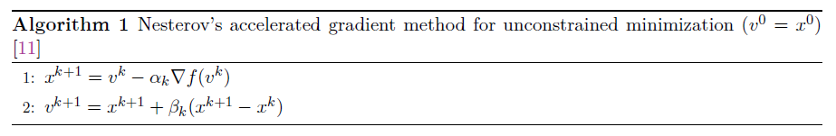

Algoritmo 1: Nesterov metodo de gradiente descendiente acelerado para minimizacion sin restriciónes

Para este tipo de configuraciones (con **convexidad estricta** y gradientes del tipo *Lipschitz* como el estimador de **Ridge**), se puede asegurar que el método converge de forma geometrica al único óptimo mínimo, si el factor de ajuste del salto $\alpha_{k}= \frac{1}{L}$

### Funciones objetivo compuestas: *suaves* y *no suaves*

La funcion objetivo de este tipo de problemas:

$$F(x) = f(x + g(x)$$

donde $f$ es una funcion convexa y $g$ es una función **no suave**. En este tipo de casos es donde resulta muy útil el uso de métodos de *gradiente-proximal* que toman ventaja de la estructura compuesta de la función objetivo y obtienen las mismas tasas de convergencia que los métodos de gradiente descendiente en problemas con funciones objetivo **suaves**

Los métodos de *gradiente-proximal* son una extension del metodo del gradiente cuando se ve el método de las iteraciones del gradiente como un problem de optimización:

$$x^{k+1} = argmin_{y\in \Re^{p}}{f(x^{k}) + \bigtriangledown f(x^{k})^{T}(y-x^{k}) + \frac{1}{2 \alpha_{k}} \left \| y - x^{k} \right \|^2 }$$
Y el resultado de ese problema es la regla de actualización que utiliza el algoritmo del metodo de *gradiente-proximal*

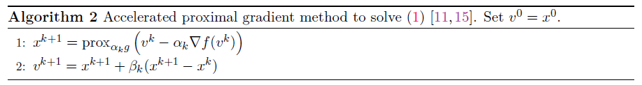

Algoritmo 2: Método de gradiente-proximal acelerado

### Funciones objetivo *no suaves*

Para este tipo de aplicaciones los métodos anteriores no son **directamente** aplicables, el problema y la función objetivo en estos casos:

$$min_{x,z \in \Re^{p}}{F(x,z) = h(x) + g(z): \Phi z=x}$$

Para este tipo de configuraciones se sugiere utilizar el algortimo que estima el óptimo por el método de *dirección alternante de los multiplicadores* (ADDM)

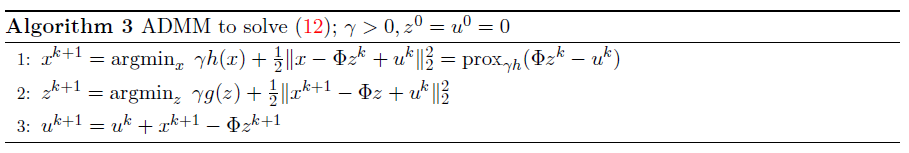

Algoritmo 3: Método de dirección alternante de los multiplicadores

Dos temas a considerar para la implementación de esta metodología:

- El algorítmo necesita calcular numericamente el paso 2
- La extención *ingenua* del algoritmo ADMM a problemas con más de dos objetivos ya no asegura la convergencia

Para la última se usan técnicas de descomposición dual para tratar multiples términos (**no suaves** dentro de la función objetivo)

## Escalabilidad para conjuntos de grandes datos mediante *aleatoriazación*

**Objetivo de la sección**

Extender las capacidades de uso de los métodos de primer órden revisados en el capitulo 1 para contextos con una gran cantidad de dimensiones (datos)

En principio los métodos de primer orden tienen la capacidad paa resolver problemas con grandes cantidades de información, sin embargo en la práctica el computo de la solución numerica, necesaria durante el proceso de iteración, puede hacer inpracticable incluso estos métodos sencillos (por el número de dimensiones).

La solución a esto es utilizar aproximaciones de los primitivos de éstos métodos como el *gradiente* o el *proximal*

### Método coordinado de descenso

En esta sección se expone el problema del `PageRank`de google:

$$min_{x\in \Re^{p}}{ F(x) = \frac{1}{2} \left \| x - \Phi x \right \|_{2}^{2} + \frac{\gamma}{2}(1_{p}^{T}x - 1)^{2}}$$

Este problema requiere calcular un producto matriz-vector en cada iteración, sin embargo puede aproximarse, de forma más barata computacionalmente, si se elige una coordenada $i$ del vector $x$ y sólo se modifica la correspondiente coordenada (esta es básicamente la idea del método coordinado de descenso).

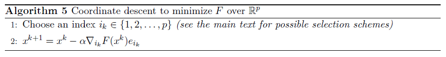

Dos características sobresaliente del métodos:

- Es idoneo para utilizarse en problemas donde la función objetivo toma la forma de $F(Ax)$ con $A \in \Re^{n \times p}$. Pues, seguir el producto de $Ax^{k}$ con incrementos, se puede actualizar el gradiente
- Un adecuado muestreo mejora significativamente la tasa de convergencia

### Métodos de Descenso *Probabilístico*

A diferencia del métodod de descenso coordinado, el método de descenso probabilisto actualiza todas las coordenadas del gradiente pero usa una aproximación. Su aplicación más clara es para minimizar problemas del tipo:

$$min_{x \in \Re^{p}}{F(x) = \frac{1}{n} \Sigma_{j=1}^{n}F_{j}(x)}$$

donde $F_{j}$ mide el la distancia en el ajuste *misfit* para cada punto.

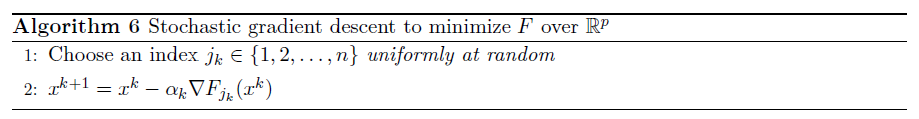

Algoritmo 4: Método de gradiente estocástico para minimizar F

La idea esencial de este metodo es la selección de los puntos $j$ aleatoriamente en lugar de ciclar sobre todos los datos. Esta idea permite utilizar el método del descenso estocástico de descenso de gradiente para funciones convexas que no tienen descomposición

Nota.- Los metodos de descenso por gradiente estocasticos son dificiles de afinar y como resultado terminan teniendo un tamaño del paso grande y promedio ponderados de las iteraciones.

### Álgebra linear aleatorizada

La idea clave detras de estos metodos es aproximar $M \approx Q(Q^{T}M) \text{ donde } Q \in \Re^{p \times r}$ o construir una representación matricial de menor rango por columna o renglon para acelear el procesamiento.

Existen tres impacto clave de este metodo:

- Se pueden acelerar los computos de operadores de proimidad que dependen de valores espectrales de una matriz
- Se pueden obtener estimadores insesgados del gradiente
- El enfoque de aleatorización puede *encojer* las funciones objetivo (aproximandolas para obtener iteraciones menos costos), pero quedandose con la misma presicipon que sobre la función objetivo original

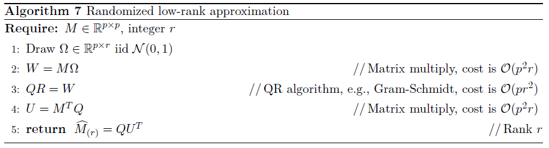

Algoritmo 5: Aproximación aleatoria de matrices de menor grado

## Procesamiento en Paralelo y Distribuido

**Objetivo de la sección**

Describir varios desarrollos relacionados con los métodos de primer órden en el contexto del computo en paralelo y/o distribuido

### Métodos *fácilmente* paralelizables

*Fácilmente* paralelizables se refiere al escenario en el cual se puede dividir el trabajo en cálculos independientes que pueden ser realizados de forma simultanea. Por l oque en principio se puede processar cada $F_{i}$ con una de $m$ computadoras usando sólo $\O(n/m)$ computos locales. Cada procesador al final se comunica con el proceso central para formar el gradiente final y así obtener un aumento lineal en el tiempo de computo.

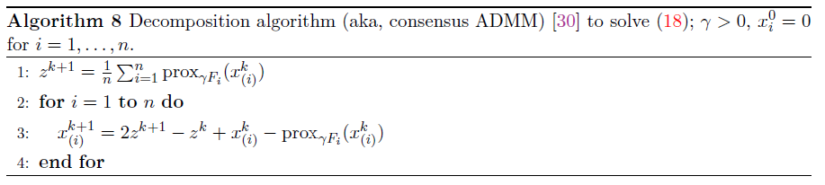

Algoritmo 6: Algoritmo de Descomposición

Existen varios ambientes, ecosistemas y softwares que permiten poner fácilmente estas ideas en acción (Hadoop, Spark, Mahout, MADlib, SystemML, BigInsights y lenguajes de alto nivel como: Pig, Hive y Jaql)

### Métodos con sistemas de comunicación restringida o descentralizada

En grandes sistema, la comunicación final del gradiente o sus elementos a un procesador central puede generar cuellos de botella. La idea basica es aplicar varias actualizaciones por el metodo de descenso coordinado al mismo tiempo en paralelo. En términos de procesamiento esto hace que cada procesador sólo necesita comunicar una única coordenada a actualizar y sólo necesita recibir la actualización de las coordenadas que cambiaron.

### Métodos Asíncronos con sistemas de comunicación descentralizada

Tanto los métodos de gradiente como la descomposición (mencionados a lo largo del capítulo) requieren de una sincronización global. En contraste, el gradiente estocástico únicmaente utiliza una aproximación del gradiente. Por lo que es robusto ante información no actualizada (las actualizaciones pueden realizarse de forma asincrona!). En la práctica esto significa que el gradiente puede ser actualizado de forma independiente por cad aprocesador. Estos métodos son ideales cuando se trabaja en contextos donde se cuenta con sistema de comunicacion descentralizados y asincoronos.